# B2 Rebound Analysis: More

Fan Bu

6/17/2020

## Checking out more predictors for time-to-rebound

### 1. Animal MHC class (“A01” positive/negative)

Below is the Kaplan-Meier curve stratified by “A01” classification. There isn’t any visible difference between the two survival curves.

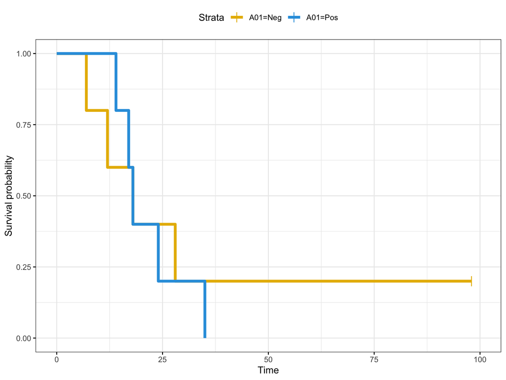

To further validate, a univariate Cox Proporational Hazards model is fit using “A01” as the predictor, and there isn’t a significant effect.

```r
phmod_A01 = coxph(Surv(rebound_time_days_post_ati, observed)~A01,
                   data = dat_log)
summary(phmod_A01)
```

```
## Call:
## coxph(formula = Surv(rebound_time_days_post_ati, observed) ~
##     A01, data = dat_log)
##
##   n= 10, number of events= 9
##
##          coef exp(coef) se(coef)     z Pr(>|z|)
## A01Pos 0.1895    1.2087   0.6786 0.279     0.78
##
##        exp(coef) exp(-coef) lower .95 upper .95
## A01Pos     1.209     0.8273    0.3196     4.571
##
## Concordance= 0.477  (se = 0.11 )
## Likelihood ratio test= 0.08  on 1 df,   p=0.8
## Wald test            = 0.08  on 1 df,   p=0.8
## Score (logrank) test = 0.08  on 1 df,   p=0.8
```

### 2. Cell counts

Absolute CD4 and CD8 cell counts (estimated by flow data + CBC, provided by Veronica) are obtained at Weeks 0, 4, 8. Here I’m using the log-transformed counts as potential predictors.

As it turns out, none of the cell counts has high concordance with rebound times, compared to other predictors tried out before.

## Regularized Cox PH model (Cox regression)

To conduct “automatic” multiple regression and variable selection, I used Cox PH model combined with elastic net (“coxnet”, implemented in package `glmnet`); specifically, for the purpose of variable selection, I used Lasso (L1 regularization, i.e., $\alpha=1$ for elastic net).

I did the following things:

1. Fit “coxnet” models with a series of $\lambda$ (regularization hyper-parameter) values, where the covaraites include:
   - **Viral load pre ART**: peak viral load, viral load at treatment & **area-under-VL-curve**
   - **Antibody response**:
     - ELISA: GP41 and GP120, peak level and level at treatment
     - Neutralization: Point IC50 & POS AUC measured at 0, 2, 4, 8 weeks post ATI
   - **Cell-associated RNA and DNA**:
     - SHIV RNA copies per million cell RNA: measured in blood, lymph node and rectal biopsy at 8 and 56 weeks post infection (RB only at 56 weeks)
     - SHIV DNA copies per million cell DNA: measured in blood, lymph node and rectal biopsy at 8, 16, 36 and 56 weeks post infection (no RB at 8 weeks)
   - **Cell counts**: Absolute CD4 and CD8 cell counts at 0, 4, 8 weeks.
   - (“A01” not included)
2. Select the $\lambda$ that yields the smallest partial deviance in cross validation and obtain the corresponding model.
3. Produce a “predictor inclusion ranking” table of the predictors based on the “coxnet” modeling results. (Note that CV with 10 data points isn’t very reliable; the best thing we can get is probably some “variable importance” ranking.)

Below are the CV plot (partial likelihood deviance vs. $\log(\lambda)$) and the selected predictors and coefficients (different runs can produce different outcomes, so it’s unstable).

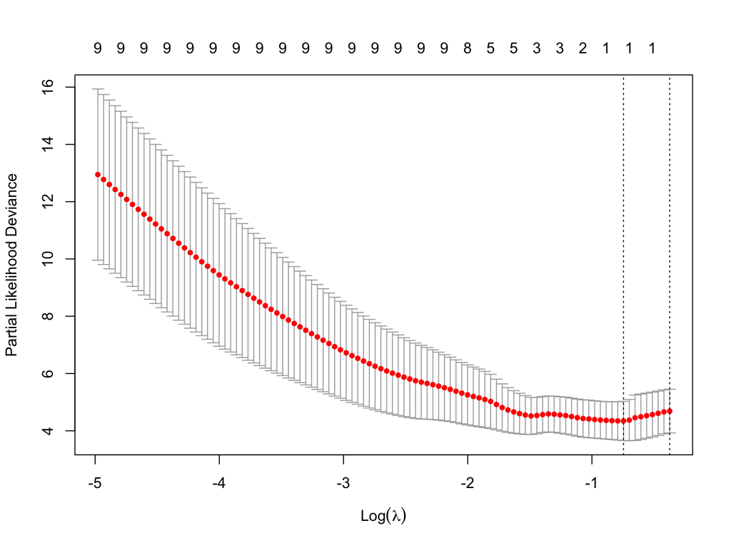

| Predictor | Coefficient |
| --- | --- |
| pos_auc_0_weeks_post_ATI | -3.7395 |

Below is the obtained “predictor inclusion ranking” table for the top 9 predictors.

| Inclusion_Rank | Predictor | Coefficient | Rebound_Effect |
| --- | --- | --- | --- |
| 1 | pos_auc_0_weeks_post_ATI | - | delay |
| 2 | log_gp41_treat | - | delay |
| 3 | log_Abs_CD8_week8 | - | delay |
| 4 | log_DNA_copies_LN_36 | - | delay |
| 5 | log_RNA_copies_blood_56 | - | delay |
| 6 | log_peak_vl | + | accelerate |
| 7 | log_DNA_copies_Blood_16 | - | delay |
| 8 | log_DNA_copies_RB_56 | + | accelerate |
| 9 | log_DNA_copies_Blood_56 | + | accelerate |

## Analysis of post-ATI viral load

I also re-explored the post-ATI viral loads, with animal `RQc19` (the one without rebound) included, as well as cell counts data.

The results did differ from last time.

Variables that correlate with `log peak VL` include:

- `log_DNA_copies_RB_36`
- `pos_auc_0_weeks_post_ATI`
- `log_point_ic50_0_weekspost_ATI`

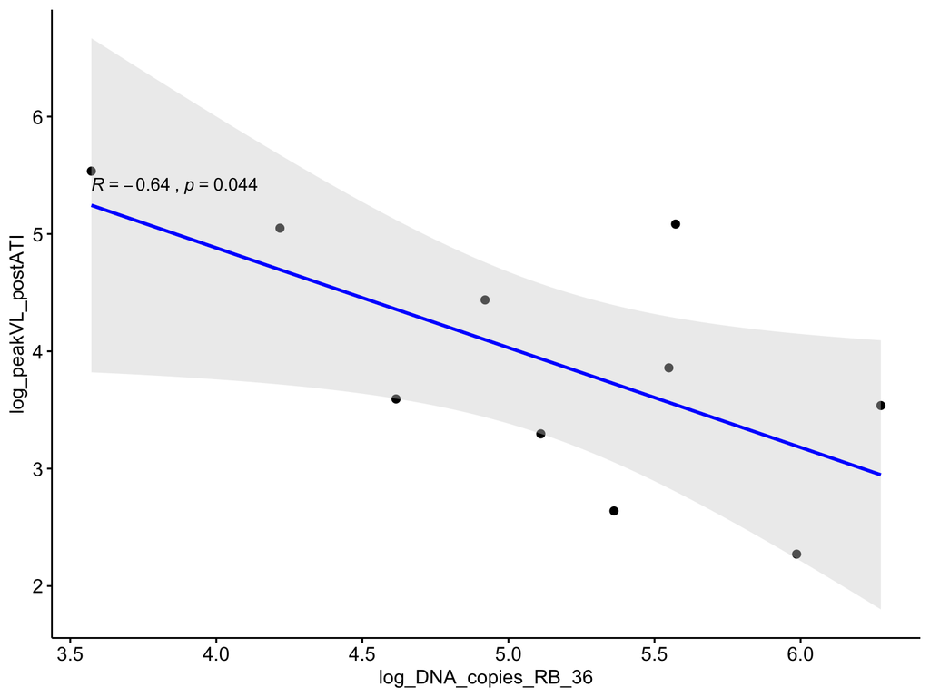

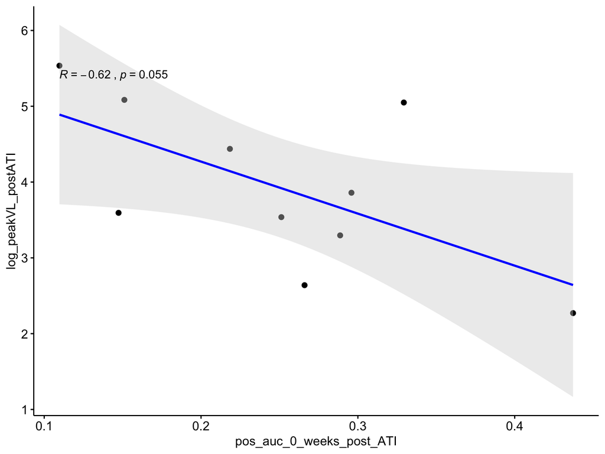

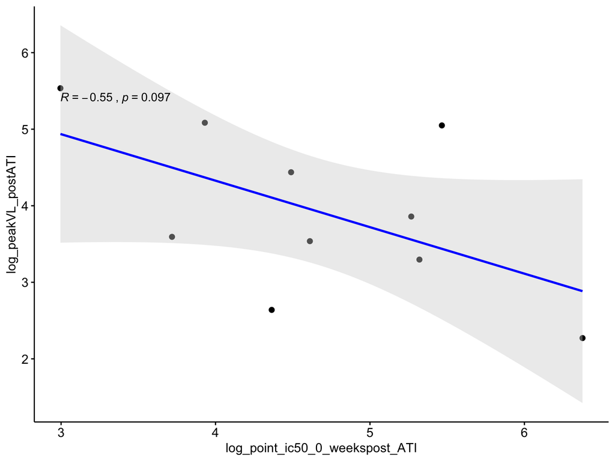

Variables that correlate with `VL AUC` include:

- `log_DNA_copies_Blood_36`
- `log_DNA_copies_RB_36`
- `log_RNA_copies_LN_8`
- etc. (followed by some other DNA & RNA measurements, and VL at treatment)

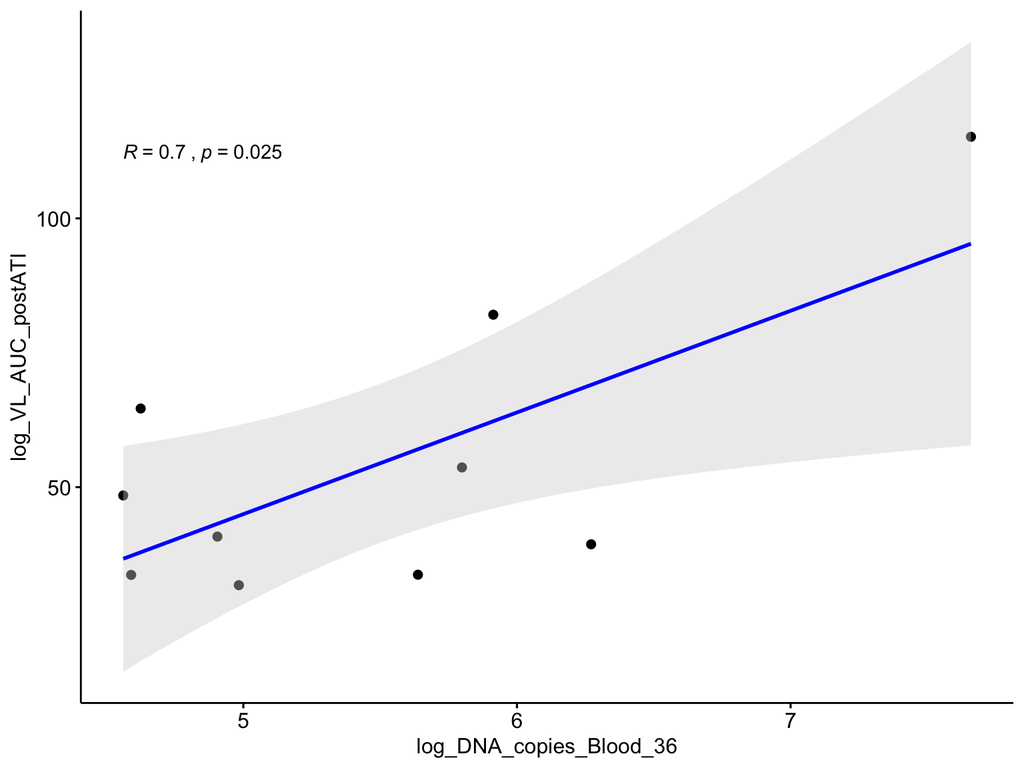

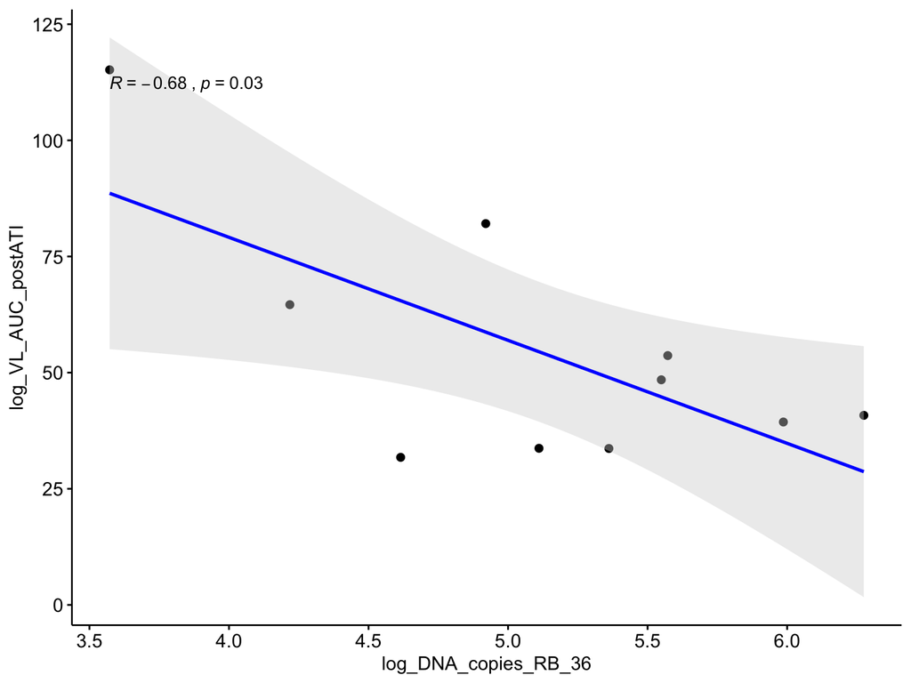

I also compared subgroups of positive `A01` vs. negative `A01` (5 monkeys each).

For “Area-under-VL-curve”, it looks like some pattern is there…

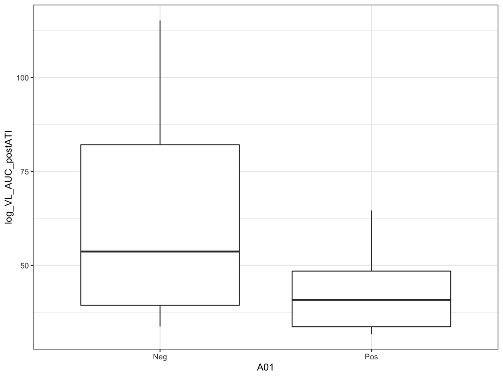

But is there??

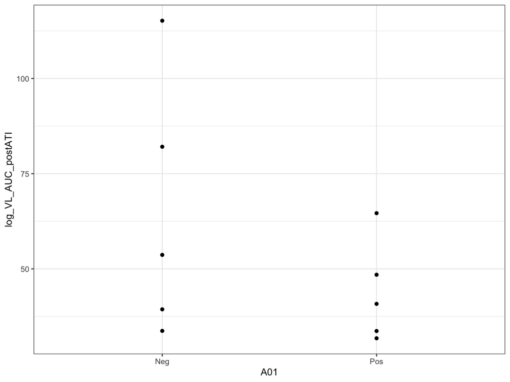

A Wilcoxon rank sum test (equivalent to the Mann-Whitney test in this case) is performed (despite the tiny sample size). There is no strong evidence to reject the null hypothesis (p-value = 0.155).